# Risk Factor Analysis

## Outcome Variable

**Outcome Variable:** wasted

## Predictor Variables

**Intervention Variable:** predfeed3

**Adjustment Set:**

- arm
- sex
- month
- brthmon
- W_mage
- meducyrs
- feducyrs
- hhwealth_quart
- hfoodsec
- W_mhtcm
- vagbrth
- W_gagebrth
- W_birthwt
- W_birthlen
- W_nrooms
- W_nchldlt5
- W_parity
- impfloor
- impsan
- safeh20
- delta_W_mage
- delta_meducyrs
- delta_feducyrs
- delta_hhwealth_quart
- delta_hfoodsec
- delta_W_mhtcm
- delta_vagbrth
- delta_W_gagebrth
- delta_W_birthwt
- delta_W_birthlen
- delta_W_nrooms
- delta_W_nchldlt5
- delta_W_parity
- delta_impfloor
- delta_impsan
- delta_safeh20

## Stratifying Variables

The analysis was stratified on these variable(s):

- agecat
- studyid
- country

## Data Summary

| agecat | studyid | country | predfeed3 | wasted | n_cell | n |
| --- | --- | --- | --- | --- | --- | --- |
| Birth | ki0047075b-MAL-ED | BANGLADESH | 0 | 0 | 29 | 227 |
| Birth | ki0047075b-MAL-ED | BANGLADESH | 0 | 1 | 5 | 227 |
| Birth | ki0047075b-MAL-ED | BANGLADESH | 1 | 0 | 160 | 227 |
| Birth | ki0047075b-MAL-ED | BANGLADESH | 1 | 1 | 33 | 227 |
| Birth | ki0047075b-MAL-ED | BRAZIL | 0 | 0 | 76 | 177 |
| Birth | ki0047075b-MAL-ED | BRAZIL | 0 | 1 | 4 | 177 |
| Birth | ki0047075b-MAL-ED | BRAZIL | 1 | 0 | 95 | 177 |
| Birth | ki0047075b-MAL-ED | BRAZIL | 1 | 1 | 2 | 177 |
| Birth | ki0047075b-MAL-ED | INDIA | 0 | 0 | 33 | 193 |
| Birth | ki0047075b-MAL-ED | INDIA | 0 | 1 | 10 | 193 |
| Birth | ki0047075b-MAL-ED | INDIA | 1 | 0 | 127 | 193 |
| Birth | ki0047075b-MAL-ED | INDIA | 1 | 1 | 23 | 193 |
| Birth | ki0047075b-MAL-ED | NEPAL | 0 | 0 | 59 | 166 |
| Birth | ki0047075b-MAL-ED | NEPAL | 0 | 1 | 10 | 166 |
| Birth | ki0047075b-MAL-ED | NEPAL | 1 | 0 | 87 | 166 |
| Birth | ki0047075b-MAL-ED | NEPAL | 1 | 1 | 10 | 166 |
| Birth | ki0047075b-MAL-ED | PERU | 0 | 0 | 86 | 265 |
| Birth | ki0047075b-MAL-ED | PERU | 0 | 1 | 2 | 265 |
| Birth | ki0047075b-MAL-ED | PERU | 1 | 0 | 173 | 265 |
| Birth | ki0047075b-MAL-ED | PERU | 1 | 1 | 4 | 265 |
| Birth | ki0047075b-MAL-ED | SOUTH AFRICA | 0 | 0 | 134 | 231 |
| Birth | ki0047075b-MAL-ED | SOUTH AFRICA | 0 | 1 | 10 | 231 |
| Birth | ki0047075b-MAL-ED | SOUTH AFRICA | 1 | 0 | 83 | 231 |
| Birth | ki0047075b-MAL-ED | SOUTH AFRICA | 1 | 1 | 4 | 231 |
| Birth | ki0047075b-MAL-ED | TANZANIA, UNITED REPUBLIC OF | 0 | 0 | 63 | 114 |
| Birth | ki0047075b-MAL-ED | TANZANIA, UNITED REPUBLIC OF | 0 | 1 | 2 | 114 |
| Birth | ki0047075b-MAL-ED | TANZANIA, UNITED REPUBLIC OF | 1 | 0 | 49 | 114 |
| Birth | ki0047075b-MAL-ED | TANZANIA, UNITED REPUBLIC OF | 1 | 1 | 0 | 114 |
| Birth | ki1000109-EE | PAKISTAN | 0 | 0 | 0 | 2 |
| Birth | ki1000109-EE | PAKISTAN | 0 | 1 | 0 | 2 |

[output cut: 94 more lines]

The following strata were considered:

- agecat: 24 months, studyid: ki0047075b-MAL-ED, country: BANGLADESH
- agecat: 24 months, studyid: ki0047075b-MAL-ED, country: BRAZIL
- agecat: 24 months, studyid: ki0047075b-MAL-ED, country: INDIA
- agecat: 24 months, studyid: ki0047075b-MAL-ED, country: NEPAL
- agecat: 24 months, studyid: ki0047075b-MAL-ED, country: PERU
- agecat: 24 months, studyid: ki0047075b-MAL-ED, country: SOUTH AFRICA
- agecat: 24 months, studyid: ki0047075b-MAL-ED, country: TANZANIA, UNITED REPUBLIC OF
- agecat: 24 months, studyid: ki1113344-GMS-Nepal, country: NEPAL
- agecat: 24 months, studyid: kiGH5241-JiVitA-3, country: BANGLADESH
- agecat: 24 months, studyid: kiGH5241-JiVitA-4, country: BANGLADESH
- agecat: 6 months, studyid: ki0047075b-MAL-ED, country: BANGLADESH
- agecat: 6 months, studyid: ki0047075b-MAL-ED, country: BRAZIL
- agecat: 6 months, studyid: ki0047075b-MAL-ED, country: INDIA
- agecat: 6 months, studyid: ki0047075b-MAL-ED, country: NEPAL
- agecat: 6 months, studyid: ki0047075b-MAL-ED, country: PERU
- agecat: 6 months, studyid: ki0047075b-MAL-ED, country: SOUTH AFRICA
- agecat: 6 months, studyid: ki0047075b-MAL-ED, country: TANZANIA, UNITED REPUBLIC OF
- agecat: 6 months, studyid: ki1000109-EE, country: PAKISTAN
- agecat: 6 months, studyid: ki1113344-GMS-Nepal, country: NEPAL
- agecat: 6 months, studyid: kiGH5241-JiVitA-3, country: BANGLADESH
- agecat: 6 months, studyid: kiGH5241-JiVitA-4, country: BANGLADESH
- agecat: Birth, studyid: ki0047075b-MAL-ED, country: BANGLADESH
- agecat: Birth, studyid: ki0047075b-MAL-ED, country: BRAZIL
- agecat: Birth, studyid: ki0047075b-MAL-ED, country: INDIA
- agecat: Birth, studyid: ki0047075b-MAL-ED, country: NEPAL
- agecat: Birth, studyid: ki0047075b-MAL-ED, country: PERU
- agecat: Birth, studyid: ki0047075b-MAL-ED, country: SOUTH AFRICA
- agecat: Birth, studyid: ki0047075b-MAL-ED, country: TANZANIA, UNITED REPUBLIC OF
- agecat: Birth, studyid: ki1000109-EE, country: PAKISTAN
- agecat: Birth, studyid: kiGH5241-JiVitA-3, country: BANGLADESH
- agecat: Birth, studyid: kiGH5241-JiVitA-4, country: BANGLADESH

### Dropped Strata

Some strata were dropped due to rare outcomes:

- agecat: Birth, studyid: ki0047075b-MAL-ED, country: BRAZIL
- agecat: Birth, studyid: ki0047075b-MAL-ED, country: PERU
- agecat: Birth, studyid: ki0047075b-MAL-ED, country: SOUTH AFRICA
- agecat: Birth, studyid: ki0047075b-MAL-ED, country: TANZANIA, UNITED REPUBLIC OF
- agecat: Birth, studyid: ki1000109-EE, country: PAKISTAN
- agecat: Birth, studyid: kiGH5241-JiVitA-4, country: BANGLADESH
- agecat: 6 months, studyid: ki0047075b-MAL-ED, country: BANGLADESH
- agecat: 6 months, studyid: ki0047075b-MAL-ED, country: BRAZIL
- agecat: 6 months, studyid: ki0047075b-MAL-ED, country: NEPAL
- agecat: 6 months, studyid: ki0047075b-MAL-ED, country: PERU
- agecat: 6 months, studyid: ki0047075b-MAL-ED, country: SOUTH AFRICA
- agecat: 6 months, studyid: ki0047075b-MAL-ED, country: TANZANIA, UNITED REPUBLIC OF
- agecat: 6 months, studyid: kiGH5241-JiVitA-4, country: BANGLADESH
- agecat: 24 months, studyid: ki0047075b-MAL-ED, country: BANGLADESH
- agecat: 24 months, studyid: ki0047075b-MAL-ED, country: BRAZIL
- agecat: 24 months, studyid: ki0047075b-MAL-ED, country: NEPAL
- agecat: 24 months, studyid: ki0047075b-MAL-ED, country: PERU
- agecat: 24 months, studyid: ki0047075b-MAL-ED, country: SOUTH AFRICA
- agecat: 24 months, studyid: ki0047075b-MAL-ED, country: TANZANIA, UNITED REPUBLIC OF

## Methods Detail

We’re interested in the causal parameters $E[Y_a]$ for all values of $a \in \mathcal{A}$. These parameters represent the mean outcome if, possibly contrary to fact, we intervened to set all units to have $A=a$. Under the randomization and positivity assumptions, these are identified by the statistical parameters $\psi_a=E_W[E_{Y|A,W}(Y|A=a,W)]$. In addition, we’re interested in the mean of $Y$, $E[Y]$ under no intervention (the observed mean). We will estimate these parameters by using SuperLearner to fit the relevant likelihood factors – $E_{Y|A,W}(Y|A=a,W)$ and $p(A=a|W)$, and then updating our likelihood fit using a joint TMLE.

For unadjusted analyses ($W=\{\}$), initial likelihoods were estimated using Lrnr_glm to estimate the simple $E(Y|A)$ and Lrnr_mean to estimate $p(A)$. For adjusted analyses, a small library containing Lrnr_glmnet, Lrnr_xgboost, and Lrnr_mean was used.

Having estimated these parameters, we will then use the delta method to estimate relative risks and attributable risks relative to a prespecified baseline level of $A$.

# Results Detail

## Results Plots

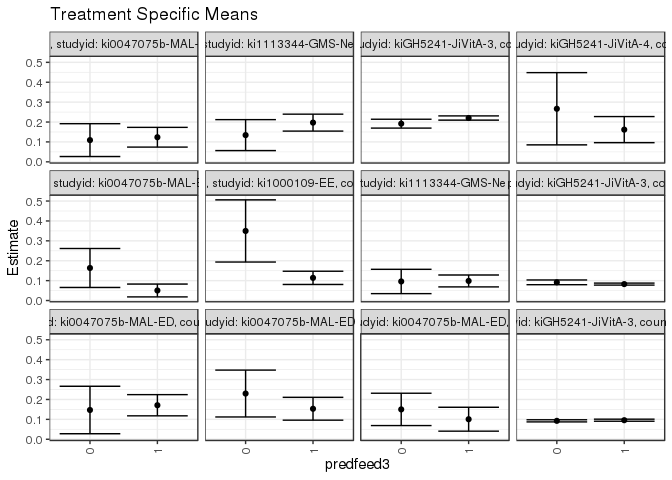

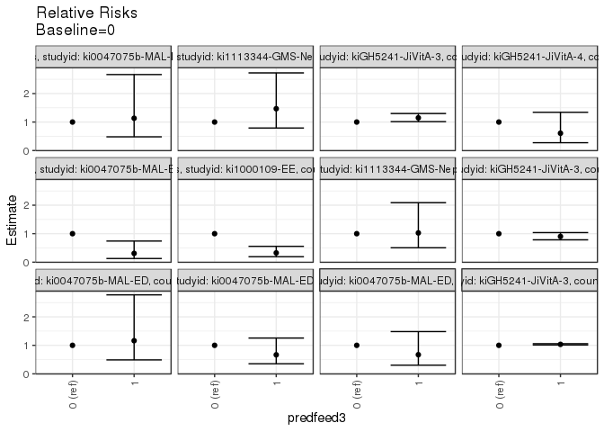

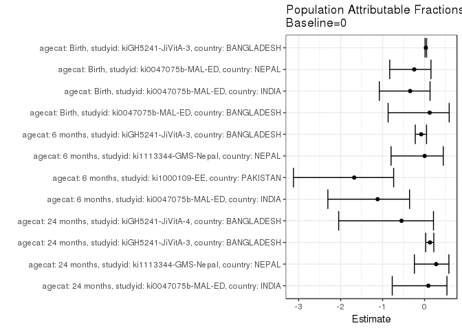

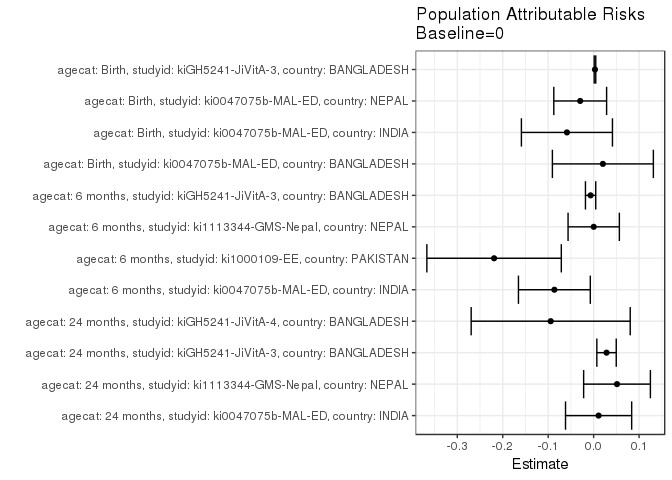

## Results Table

### Parameter: TSM

| agecat | studyid | country | intervention_level | baseline_level | estimate | ci_lower | ci_upper |
| --- | --- | --- | --- | --- | --- | --- | --- |
| Birth | ki0047075b-MAL-ED | BANGLADESH | 0 | NA | 0.1470588 | 0.0277500 | 0.2663676 |
| Birth | ki0047075b-MAL-ED | BANGLADESH | 1 | NA | 0.1709845 | 0.1177506 | 0.2242183 |
| Birth | ki0047075b-MAL-ED | INDIA | 0 | NA | 0.2297510 | 0.1119377 | 0.3475642 |
| Birth | ki0047075b-MAL-ED | INDIA | 1 | NA | 0.1532769 | 0.0958543 | 0.2106994 |
| Birth | ki0047075b-MAL-ED | NEPAL | 0 | NA | 0.1500462 | 0.0688475 | 0.2312448 |
| Birth | ki0047075b-MAL-ED | NEPAL | 1 | NA | 0.1006734 | 0.0405741 | 0.1607728 |
| Birth | kiGH5241-JiVitA-3 | BANGLADESH | 0 | NA | 0.0925976 | 0.0871741 | 0.0980211 |
| Birth | kiGH5241-JiVitA-3 | BANGLADESH | 1 | NA | 0.0957390 | 0.0904756 | 0.1010024 |
| 6 months | ki0047075b-MAL-ED | INDIA | 0 | NA | 0.1636364 | 0.0656562 | 0.2616165 |
| 6 months | ki0047075b-MAL-ED | INDIA | 1 | NA | 0.0505618 | 0.0183053 | 0.0828183 |
| 6 months | ki1000109-EE | PAKISTAN | 0 | NA | 0.3497030 | 0.1934592 | 0.5059469 |
| 6 months | ki1000109-EE | PAKISTAN | 1 | NA | 0.1140321 | 0.0808160 | 0.1472482 |
| 6 months | ki1113344-GMS-Nepal | NEPAL | 0 | NA | 0.0959009 | 0.0347436 | 0.1570581 |
| 6 months | ki1113344-GMS-Nepal | NEPAL | 1 | NA | 0.0984929 | 0.0686338 | 0.1283520 |
| 6 months | kiGH5241-JiVitA-3 | BANGLADESH | 0 | NA | 0.0915413 | 0.0796004 | 0.1034821 |
| 6 months | kiGH5241-JiVitA-3 | BANGLADESH | 1 | NA | 0.0826398 | 0.0775979 | 0.0876817 |
| 24 months | ki0047075b-MAL-ED | INDIA | 0 | NA | 0.1090909 | 0.0265166 | 0.1916652 |
| 24 months | ki0047075b-MAL-ED | INDIA | 1 | NA | 0.1235294 | 0.0739565 | 0.1731024 |
| 24 months | ki1113344-GMS-Nepal | NEPAL | 0 | NA | 0.1342081 | 0.0564187 | 0.2119976 |
| 24 months | ki1113344-GMS-Nepal | NEPAL | 1 | NA | 0.1969968 | 0.1544829 | 0.2395106 |
| 24 months | kiGH5241-JiVitA-3 | BANGLADESH | 0 | NA | 0.1917468 | 0.1695644 | 0.2139292 |
| 24 months | kiGH5241-JiVitA-3 | BANGLADESH | 1 | NA | 0.2201364 | 0.2095122 | 0.2307606 |
| 24 months | kiGH5241-JiVitA-4 | BANGLADESH | 0 | NA | 0.2666667 | 0.0851884 | 0.4481449 |
| 24 months | kiGH5241-JiVitA-4 | BANGLADESH | 1 | NA | 0.1617647 | 0.0961979 | 0.2273315 |

### Parameter: E(Y)

| agecat | studyid | country | intervention_level | baseline_level | estimate | ci_lower | ci_upper |
| --- | --- | --- | --- | --- | --- | --- | --- |
| Birth | ki0047075b-MAL-ED | BANGLADESH | NA | NA | 0.1674009 | 0.1187276 | 0.2160742 |
| Birth | ki0047075b-MAL-ED | INDIA | NA | NA | 0.1709845 | 0.1177299 | 0.2242391 |
| Birth | ki0047075b-MAL-ED | NEPAL | NA | NA | 0.1204819 | 0.0708125 | 0.1701514 |
| Birth | kiGH5241-JiVitA-3 | BANGLADESH | NA | NA | 0.0955338 | 0.0902714 | 0.1007962 |
| 6 months | ki0047075b-MAL-ED | INDIA | NA | NA | 0.0772532 | 0.0428971 | 0.1116093 |
| 6 months | ki1000109-EE | PAKISTAN | NA | NA | 0.1306667 | 0.0965090 | 0.1648243 |
| 6 months | ki1113344-GMS-Nepal | NEPAL | NA | NA | 0.0960699 | 0.0690520 | 0.1230877 |
| 6 months | kiGH5241-JiVitA-3 | BANGLADESH | NA | NA | 0.0848459 | 0.0799494 | 0.0897424 |
| 24 months | ki0047075b-MAL-ED | INDIA | NA | NA | 0.1200000 | 0.0774445 | 0.1625555 |
| 24 months | ki1113344-GMS-Nepal | NEPAL | NA | NA | 0.1856436 | 0.1476821 | 0.2236050 |
| 24 months | kiGH5241-JiVitA-3 | BANGLADESH | NA | NA | 0.2201371 | 0.2099559 | 0.2303184 |
| 24 months | kiGH5241-JiVitA-4 | BANGLADESH | NA | NA | 0.1721854 | 0.1107033 | 0.2336676 |

### Parameter: RR

| agecat | studyid | country | intervention_level | baseline_level | estimate | ci_lower | ci_upper |
| --- | --- | --- | --- | --- | --- | --- | --- |
| Birth | ki0047075b-MAL-ED | BANGLADESH | 0 | 0 | 1.0000000 | 1.0000000 | 1.0000000 |
| Birth | ki0047075b-MAL-ED | BANGLADESH | 1 | 0 | 1.1626943 | 0.4876063 | 2.7724374 |
| Birth | ki0047075b-MAL-ED | INDIA | 0 | 0 | 1.0000000 | 1.0000000 | 1.0000000 |
| Birth | ki0047075b-MAL-ED | INDIA | 1 | 0 | 0.6671436 | 0.3542639 | 1.2563532 |
| Birth | ki0047075b-MAL-ED | NEPAL | 0 | 0 | 1.0000000 | 1.0000000 | 1.0000000 |
| Birth | ki0047075b-MAL-ED | NEPAL | 1 | 0 | 0.6709499 | 0.3037141 | 1.4822283 |
| Birth | kiGH5241-JiVitA-3 | BANGLADESH | 0 | 0 | 1.0000000 | 1.0000000 | 1.0000000 |
| Birth | kiGH5241-JiVitA-3 | BANGLADESH | 1 | 0 | 1.0339246 | 1.0123412 | 1.0559683 |
| 6 months | ki0047075b-MAL-ED | INDIA | 0 | 0 | 1.0000000 | 1.0000000 | 1.0000000 |
| 6 months | ki0047075b-MAL-ED | INDIA | 1 | 0 | 0.3089888 | 0.1288136 | 0.7411798 |
| 6 months | ki1000109-EE | PAKISTAN | 0 | 0 | 1.0000000 | 1.0000000 | 1.0000000 |
| 6 months | ki1000109-EE | PAKISTAN | 1 | 0 | 0.3260827 | 0.1913564 | 0.5556642 |
| 6 months | ki1113344-GMS-Nepal | NEPAL | 0 | 0 | 1.0000000 | 1.0000000 | 1.0000000 |
| 6 months | ki1113344-GMS-Nepal | NEPAL | 1 | 0 | 1.0270284 | 0.5050197 | 2.0886062 |
| 6 months | kiGH5241-JiVitA-3 | BANGLADESH | 0 | 0 | 1.0000000 | 1.0000000 | 1.0000000 |
| 6 months | kiGH5241-JiVitA-3 | BANGLADESH | 1 | 0 | 0.9027605 | 0.7846898 | 1.0385969 |
| 24 months | ki0047075b-MAL-ED | INDIA | 0 | 0 | 1.0000000 | 1.0000000 | 1.0000000 |
| 24 months | ki0047075b-MAL-ED | INDIA | 1 | 0 | 1.1323529 | 0.4807371 | 2.6672023 |
| 24 months | ki1113344-GMS-Nepal | NEPAL | 0 | 0 | 1.0000000 | 1.0000000 | 1.0000000 |
| 24 months | ki1113344-GMS-Nepal | NEPAL | 1 | 0 | 1.4678452 | 0.7907839 | 2.7245994 |
| 24 months | kiGH5241-JiVitA-3 | BANGLADESH | 0 | 0 | 1.0000000 | 1.0000000 | 1.0000000 |
| 24 months | kiGH5241-JiVitA-3 | BANGLADESH | 1 | 0 | 1.1480577 | 1.0143821 | 1.2993492 |
| 24 months | kiGH5241-JiVitA-4 | BANGLADESH | 0 | 0 | 1.0000000 | 1.0000000 | 1.0000000 |
| 24 months | kiGH5241-JiVitA-4 | BANGLADESH | 1 | 0 | 0.6066176 | 0.2741503 | 1.3422748 |

### Parameter: PAR

| agecat | studyid | country | intervention_level | baseline_level | estimate | ci_lower | ci_upper |
| --- | --- | --- | --- | --- | --- | --- | --- |
| Birth | ki0047075b-MAL-ED | BANGLADESH | 0 | NA | 0.0203421 | -0.0907416 | 0.1314257 |
| Birth | ki0047075b-MAL-ED | INDIA | 0 | NA | -0.0587665 | -0.1589377 | 0.0414047 |
| Birth | ki0047075b-MAL-ED | NEPAL | 0 | NA | -0.0295642 | -0.0876666 | 0.0285382 |
| Birth | kiGH5241-JiVitA-3 | BANGLADESH | 0 | NA | 0.0029362 | 0.0012126 | 0.0046598 |
| 6 months | ki0047075b-MAL-ED | INDIA | 0 | NA | -0.0863831 | -0.1654288 | -0.0073375 |
| 6 months | ki1000109-EE | PAKISTAN | 0 | NA | -0.2190364 | -0.3669521 | -0.0711207 |
| 6 months | ki1113344-GMS-Nepal | NEPAL | 0 | NA | 0.0001690 | -0.0562617 | 0.0565998 |
| 6 months | kiGH5241-JiVitA-3 | BANGLADESH | 0 | NA | -0.0066954 | -0.0180039 | 0.0046131 |
| 24 months | ki0047075b-MAL-ED | INDIA | 0 | NA | 0.0109091 | -0.0618645 | 0.0836827 |
| 24 months | ki1113344-GMS-Nepal | NEPAL | 0 | NA | 0.0514354 | -0.0220066 | 0.1248775 |
| 24 months | kiGH5241-JiVitA-3 | BANGLADESH | 0 | NA | 0.0283903 | 0.0070456 | 0.0497350 |
| 24 months | kiGH5241-JiVitA-4 | BANGLADESH | 0 | NA | -0.0944812 | -0.2694561 | 0.0804936 |

### Parameter: PAF

| agecat | studyid | country | intervention_level | baseline_level | estimate | ci_lower | ci_upper |
| --- | --- | --- | --- | --- | --- | --- | --- |
| Birth | ki0047075b-MAL-ED | BANGLADESH | 0 | NA | 0.1215170 | -0.8684646 | 0.5869698 |
| Birth | ki0047075b-MAL-ED | INDIA | 0 | NA | -0.3436950 | -1.0774927 | 0.1309157 |
| Birth | ki0047075b-MAL-ED | NEPAL | 0 | NA | -0.2453831 | -0.8305728 | 0.1527357 |
| Birth | kiGH5241-JiVitA-3 | BANGLADESH | 0 | NA | 0.0307346 | 0.0125619 | 0.0485728 |
| 6 months | ki0047075b-MAL-ED | INDIA | 0 | NA | -1.1181818 | -2.3044780 | -0.3577619 |
| 6 months | ki1000109-EE | PAKISTAN | 0 | NA | -1.6762988 | -3.1241339 | -0.7367465 |
| 6 months | ki1113344-GMS-Nepal | NEPAL | 0 | NA | 0.0017593 | -0.7979358 | 0.4457619 |
| 6 months | kiGH5241-JiVitA-3 | BANGLADESH | 0 | NA | -0.0789123 | -0.2212958 | 0.0468715 |
| 24 months | ki0047075b-MAL-ED | INDIA | 0 | NA | 0.0909091 | -0.7701630 | 0.5331242 |
| 24 months | ki1113344-GMS-Nepal | NEPAL | 0 | NA | 0.2770655 | -0.2427909 | 0.5794673 |
| 24 months | kiGH5241-JiVitA-3 | BANGLADESH | 0 | NA | 0.1289666 | 0.0272315 | 0.2200619 |
| 24 months | kiGH5241-JiVitA-4 | BANGLADESH | 0 | NA | -0.5487179 | -2.0466898 | 0.2127432 |